# Automated data download

Author

Brendan Turley

This is a quick tutorial on different ways to download data for use in [R](https://www.r-project.org). While there are lots of different types of data and different data sources (we could spend multiple sessions talking about just that), this will focus on gridded data easily accessible from NOAA stored in [NetCDF](https://www.unidata.ucar.edu/software/netcdf/) format following the [Adapt NE SOE Indicator tutorial](http://htmlpreview.github.io/?https://github.com/Gulf-IEA/Seaside-chats/blob/main/Tutorials/Adapt%20NE%20SoE%20Indicator.html) by downloading OISST anomaly data.

First, some R housekeeping by loading needed libraries. I will be keeping this simple by using minimal packages (sorry tidyverse folks).

```r
library(cmocean)
library(fields)
library(ncdf4)
library(rerddap)
library(rgdal)
```

## 1. Manual download and plotting

The NEFSC Ecodata package pulls the data from [NOAA’s Physical Science Laboratory website](https://psl.noaa.gov/data/gridded/data.noaa.oisst.v2.highres.html). You can download the data manually by selecting the download daily SST anomaly [link](https://downloads.psl.noaa.gov/Datasets/noaa.oisst.v2.highres/). Then, download the 2023 daily SST anomaly [netcdf](https://psl.noaa.gov/thredds/catalog/Datasets/noaa.oisst.v2.highres/catalog.html?dataset=Datasets/noaa.oisst.v2.highres/sst.day.anom.2023.nc) select *‘HTTPServer’* to download the file on to you computer and open Netcdf file in R like this:

```r
setwd('~/Downloads')

data <- nc_open('sst.day.anom.2023.nc')

data
```

```
File sst.day.anom.2023.nc (NC_FORMAT_NETCDF4_CLASSIC):

     1 variables (excluding dimension variables):
        float anom[lon,lat,time]   (Chunking: [1440,720,1])  (Compression: shuffle,level 2)
            long_name: Daily Sea Surface Temperature Anomalies
            units: degC
            valid_range: -25
             valid_range: 25
            missing_value: -9.96920996838687e+36
            precision: 2
            dataset: NOAA High-resolution Blended Analysis
            var_desc: Sea Surface Temperature Anomalies
            level_desc: Surface
            statistic: Anomaly
            parent_stat: Other
            actual_range: -11.9299993515015
             actual_range: 11.9799995422363

     3 dimensions:
        time  Size:101   *** is unlimited ***
            long_name: Time
            units: days since 1800-01-01 00:00:00
            delta_t: 0000-00-01 00:00:00
            avg_period: 0000-00-01 00:00:00
            axis: T
            actual_range: 81449
             actual_range: 81549
        lat  Size:720
            long_name: Latitude
            standard_name: latitude
            units: degrees_north
            actual_range: -89.875
             actual_range: 89.875
            axis: Y
        lon  Size:1440
            long_name: Longitude
            standard_name: longitude
            units: degrees_east
            actual_range: 0.125
             actual_range: 359.875
            axis: X

    8 global attributes:
        Conventions: CF-1.5
        title: NOAA/NCEI 1/4 Degree Daily Optimum Interpolation Sea Surface Temperature (OISST) Analysis, Version 2.1
        institution: NOAA/National Centers for Environmental Information
        source: NOAA/NCEI https://www.ncei.noaa.gov/data/sea-surface-temperature-optimum-interpolation/v2.1/access/avhrr/
        References: https://www.psl.noaa.gov/data/gridded/data.noaa.oisst.v2.highres.html
        dataset_title: NOAA Daily Optimum Interpolation Sea Surface Temperature
        version: Version 2.1
        comment: Reynolds, et al.(2007) Daily High-Resolution-Blended Analyses for Sea Surface Temperature (available at https://doi.org/10.1175/2007JCLI1824.1). Banzon, et al.(2016) A long-term record of blended satellite and in situ sea-surface temperature for climate monitoring, modeling and envi…
```

Now, lets pull out the dimensional variables: time, longitude, and latitude.

```r
time <- ncvar_get(data, 'time')
time <- as.Date(time, origin = '1800-01-01 00:00:00')

lon <- ncvar_get(data, 'lon')
lat <- ncvar_get(data, 'lat')
```

Then pull the missing data value and SST anomaly data, then assign the missing values and check out the dimensions.

```r
missing <- ncatt_get(data, 'anom' ,'missing_value')
ssta <- ncvar_get(data, 'anom')

ssta[which(ssta == missing$value)] <- NA

dim(ssta)
```

```
[1] 1440  720  101
```

The order of the dimension are lon, lat and, time. That’s global data, but we only want the Gulf of Mexico in this example. Define the region of interest, extract only the important bits, and plot.

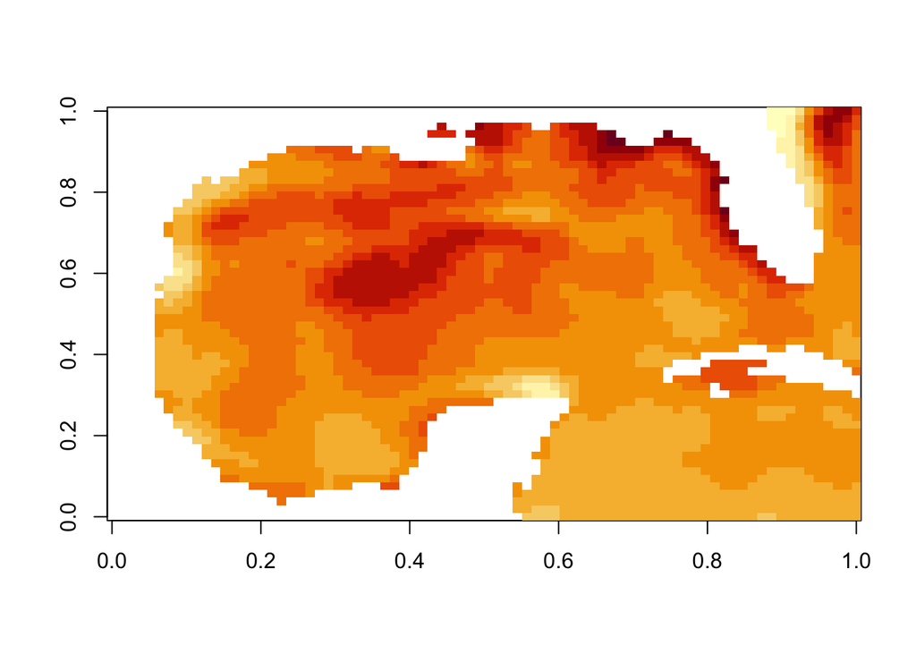

```r
# define GOM
lonbox_e <- -79 + 360
lonbox_w <- -99 + 360
latbox_n <- 31
latbox_s <- 17.5

# indices for GOM lon/lat
ind_lon <- which(lon>=lonbox_w & lon<=lonbox_e)
ind_lat <- which(lat>=latbox_s & lat<=latbox_n)

# only extract GOM
ssta <- ncvar_get(data, 'anom',
                  start = c(ind_lon[1], ind_lat[1], 1),
                  count = c(length(ind_lon), length(ind_lat), length(time)))

ssta[which(ssta == missing$value)] <- NA

image(ssta[ , , 100])
```

Looks like the Gulf of Mexico. But let’s make a prettier plot.

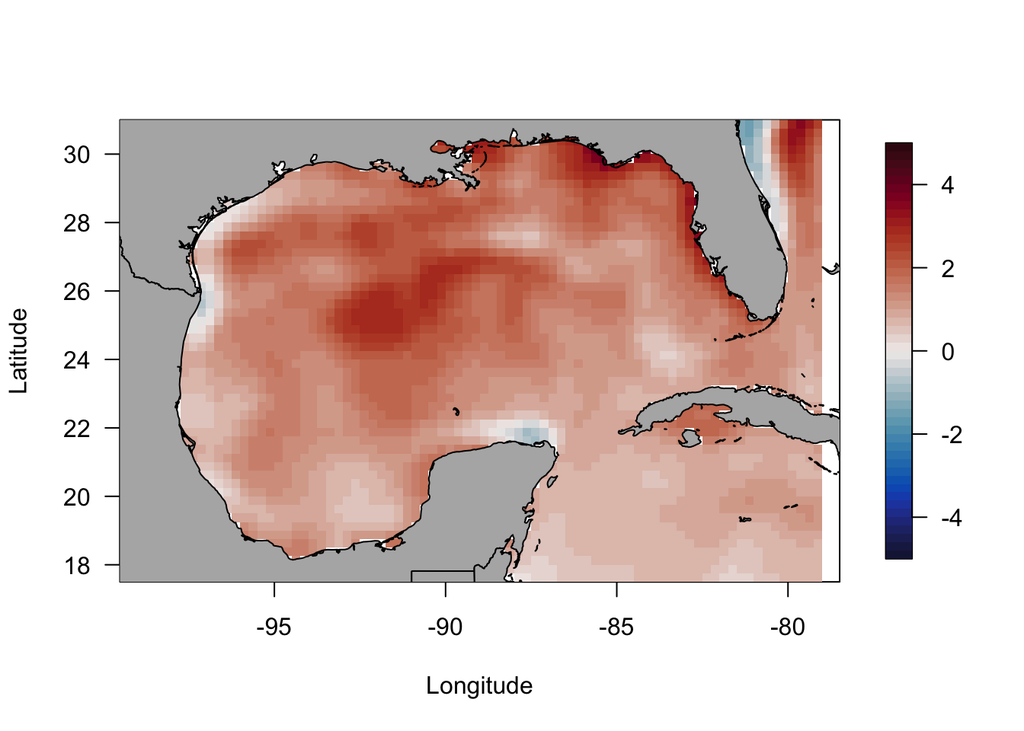

```r
### load map
setwd("~/Desktop/professional/biblioteca/data/shapefiles/ne_10m_admin_0_countries")
world <- readOGR('ne_10m_admin_0_countries.shp')
imagePlot(lon[ind_lon] - 360,
          lat[ind_lat],
          ssta[ , , 100],
          asp = 1, las = 1, xlab = 'Longitude', ylab = 'Latitude',
          col = cmocean('balance')(50), breaks = seq(-5,5,.2))
plot(world, add=T, col = 'gray70')
```

## 2. Automated download via THREDDS/OpenDAP

Now lets do this via [THREDDS](https://www.unidata.ucar.edu/software/tds/) and [OpenDAP](https://www.opendap.org). You can go to the [THREDDS server catalog](https://psl.noaa.gov/thredds/catalog/Datasets/noaa.oisst.v2.highres/catalog.html). Click on the daily SST anomaly for 2023 [link](https://psl.noaa.gov/thredds/catalog/Datasets/noaa.oisst.v2.highres/catalog.html?dataset=Datasets/noaa.oisst.v2.highres/sst.day.anom.2023.nc), then click the [OpenDAP link](https://psl.noaa.gov/thredds/dodsC/Datasets/noaa.oisst.v2.highres/sst.day.mean.2023.nc.html). Here you can view all the metadata for the file. Find the *Data URL* field, copy that link, and paste into R. From there you can open the Netcdf file directly in R without manual download and extract everything like we did above with the same code.

```r
rm(list=ls()) # sanity check

### load map
setwd("~/Desktop/professional/biblioteca/data/shapefiles/ne_10m_admin_0_countries")
world <- readOGR('ne_10m_admin_0_countries.shp')
### data URL
url <- 'http://psl.noaa.gov/thredds/dodsC/Datasets/noaa.oisst.v2.highres/sst.day.anom.2023.nc'

data <- nc_open(url)

data
```

```
File http://psl.noaa.gov/thredds/dodsC/Datasets/noaa.oisst.v2.highres/sst.day.anom.2023.nc (NC_FORMAT_CLASSIC):

     1 variables (excluding dimension variables):
        float anom[lon,lat,time]
            long_name: Daily Sea Surface Temperature Anomalies
            units: degC
            valid_range: -25
             valid_range: 25
            missing_value: -9.96920996838687e+36
            precision: 2
            dataset: NOAA High-resolution Blended Analysis
            var_desc: Sea Surface Temperature Anomalies
            level_desc: Surface
            statistic: Anomaly
            parent_stat: Other
            actual_range: -11.9299993515015
             actual_range: 11.9799995422363
            _ChunkSizes: 1
             _ChunkSizes: 720
             _ChunkSizes: 1440

     3 dimensions:
        time  Size:103   *** is unlimited ***
            long_name: Time
            units: days since 1800-01-01 00:00:00
            delta_t: 0000-00-01 00:00:00
            avg_period: 0000-00-01 00:00:00
            axis: T
            actual_range: 81449
             actual_range: 81551
            _ChunkSizes: 512
        lat  Size:720
            long_name: Latitude
            standard_name: latitude
            units: degrees_north
            actual_range: -89.875
             actual_range: 89.875
            axis: Y
        lon  Size:1440
            long_name: Longitude
            standard_name: longitude
            units: degrees_east
            actual_range: 0.125
             actual_range: 359.875
            axis: X

    10 global attributes:
        Conventions: CF-1.5
        _NCProperties: version=2,netcdf=4.7.0,hdf5=1.10.5,
        title: NOAA/NCEI 1/4 Degree Daily Optimum Interpolation Sea Surface Temperature (OISST) Analysis, Version 2.1
        institution: NOAA/National Centers for Environmental Information
        source: NOAA/NCEI https://www.ncei.noaa.gov/data/sea-surface-temperature-optimum-interpolation/v2.1/access/avhrr/
        References: https://www.psl.noaa.gov/data/gridded/data.noaa.oisst.v2.highres.html
        dataset_title: NOAA Daily Optimum Interpolation Sea Surface Temperature
        version: Version 2.1
        comment: Reynolds, et al.(2007) Daily High-Resolution-Blended Analyses for Sea Surface Temperature (available at https://doi.org/10.1175/2007JCLI1824.1). Banzon, et al.(2016) A long-term record of blended satellite and in situ sea-surface temperature for climate monitoring, modeling and envi…
        DODS_EXTRA.Unlimited_Dimension: time
```

```r
### get dims
time <- ncvar_get(data, 'time')
time <- as.Date(time, origin = '1800-01-01 00:00:00')

lon <- ncvar_get(data, 'lon')
lat <- ncvar_get(data, 'lat')

### get missing value
missing <- ncatt_get(data, 'anom' ,'missing_value')

# define GOM
lonbox_e <- -79 + 360
lonbox_w <- -99 + 360
latbox_n <- 31
latbox_s <- 17.5

# indices for GOM lon/lat
ind_lon <- which(lon>=lonbox_w & lon<=lonbox_e)
ind_lat <- which(lat>=latbox_s & lat<=latbox_n)

# only extract GOM
ssta <- ncvar_get(data,'anom',
                  start=c(ind_lon[1],ind_lat[1],1),
                  count=c(length(ind_lon),length(ind_lat),length(time)))
ssta[which(ssta == missing$value)] <- NA
dim(ssta)
```

```
[1]  80  54 103
```

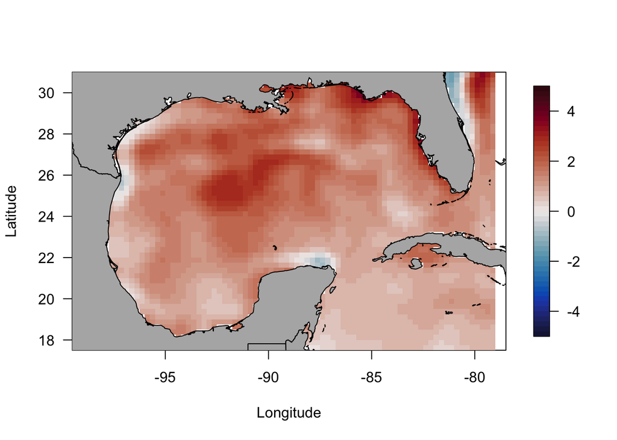

```r
imagePlot(lon[ind_lon] - 360,
          lat[ind_lat],
          ssta[ , , 100],
          asp = 1, las = 1, xlab = 'Longitude', ylab = 'Latitude',
          col = cmocean('balance')(50), breaks = seq(-5,5,.2))
plot(world, add=T, col = 'gray70')
```

Should be the exact thing as in the first section.

## 3. Automated download via ERDDAP

From [NOAA NCEI Climate Data Records](https://www.ncei.noaa.gov/products/climate-data-records/sea-surface-temperature-optimum-interpolation) there is a link to an [ERDDAP server](https://www.ncei.noaa.gov/erddap/search/index.html?page=1&itemsPerPage=1000&searchFor=OISST) with this dataset. Since we’re interested in 2023, use the Prelimary data. From there, you can generate an API link to download the part you wnat, but someone made a handy [ERDDAP R package](https://docs.ropensci.org/rerddap/). We’re only going to use the package here. From the ERDDAP server all you need is the *Dataset ID*. Paste that into the RERDDAP *info* function and specify which ERDDAP server you want:

```r
ssta_pull <- info('ncdc_oisst_v2_avhrr_prelim_by_time_zlev_lat_lon',
                  url = 'https://www.ncei.noaa.gov/erddap/')
ssta_pull
```

```
<ERDDAP info> ncdc_oisst_v2_avhrr_prelim_by_time_zlev_lat_lon
 Base URL: https://www.ncei.noaa.gov/erddap
 Dataset Type: griddap
 Dimensions (range):
     time: (2023-03-28T12:00:00Z, 2023-04-10T12:00:00Z)
     depth: (0.0, 0.0)
     latitude: (-89.875, 89.875)
     longitude: (0.125, 359.875)
 Variables:
     anom:
         Units: Celsius
     err:
         Units: Celsius
     ice:
         Units: %
     sst:
         Units: Celsius
```

Now define the spatial temporal section you want and extract:

```r
latitude = c(latbox_s, latbox_n)
longitude = c(lonbox_w, lonbox_e)

ssta_grab <- griddap(ssta_pull,
                     time = c('2023-03-29', '2023-04-10'),
                     latitude = latitude,
                     longitude = longitude,
                     fields = 'anom')
ssta_grab
```

```
<ERDDAP griddap> ncdc_oisst_v2_avhrr_prelim_by_time_zlev_lat_lon
   Path: [/var/folders/7f/kk27hkgx2x55ydsp9pndzfx40000gn/T//Rtmpc04Lkz/R/rerddap/26b4753e7f55080dd491018532d8446a.nc]
   Last updated: [2023-04-14 12:58:42]
   File size:    [0.24 mb]
   Dimensions (dims/vars):   [4 X 1]
   Dim names: time, depth, latitude, longitude
   Variable names: Daily sea surface temperature anomalies
   data.frame (rows/columns):   [57915 X 5]
# A tibble: 57,915 × 5
   longitude  latitude     depth time                  anom
   <dbl[1d]> <dbl[1d]> <dbl[1d]> <chr>                <dbl>
 1      261.      17.6         0 2023-03-29T12:00:00Z   NaN
 2      261.      17.6         0 2023-03-29T12:00:00Z   NaN
 3      262.      17.6         0 2023-03-29T12:00:00Z   NaN
 4      262.      17.6         0 2023-03-29T12:00:00Z   NaN
 5      262.      17.6         0 2023-03-29T12:00:00Z   NaN
 6      262.      17.6         0 2023-03-29T12:00:00Z   NaN
 7      263.      17.6         0 2023-03-29T12:00:00Z   NaN
 8      263.      17.6         0 2023-03-29T12:00:00Z   NaN
 9      263.      17.6         0 2023-03-29T12:00:00Z   NaN
10      263.      17.6         0 2023-03-29T12:00:00Z   NaN
# ℹ 57,905 more rows
```

The output format is not convenient to plot as I have been plotting, so I made a function rearrange the output to be more how I like it:

```r
erddap_extract <- function(data, info, parameter){
  data_temp <- data$data
  ind_extract <- which(names(data_temp)==parameter)
  time_step <- unique(data_temp$time)
  lon <- data$summary$dim$longitude$vals
  lat <- data$summary$dim$latitude$vals

  new_data <- array(data_temp[,ind_extract],
                    c(length(lon),
                      length(lat),
                      length(time_step)))

  row_ind <- which(info$alldata$NC_GLOBAL$attribute_name=='title')
  col_ind <- which(colnames(info$alldata$NC_GLOBAL)=='value')
  name <- info$alldata$NC_GLOBAL[row_ind,col_ind]
  name <- unlist(strsplit(name,split=','))
  return(list(data = new_data,
              lon = lon,
              lat = lat,
              time = time_step,
              name = name))
}
```

Then extract the data, assign NAs to NaN (the plotting function didn’t like NaN), and plot like before:

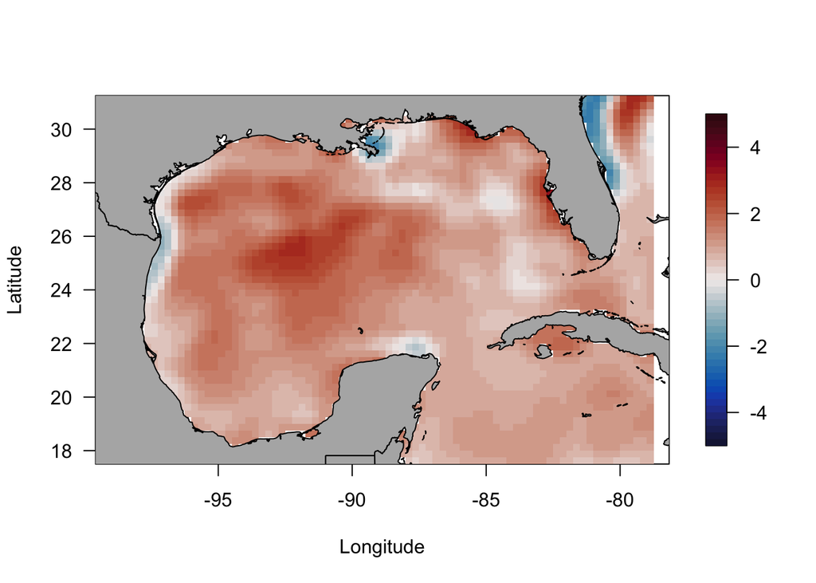

```r
ssta_m <- erddap_extract(ssta_grab,ssta_pull,'anom')
ssta_m$data[which(ssta_m$data=='NaN')] <- NA

imagePlot(ssta_m$lon - 360,
          ssta_m$lat,
          ssta_m$data[ , , 13],
          asp = 1, las = 1, xlab = 'Longitude', ylab = 'Latitude',
          col = cmocean('balance')(50), breaks = seq(-5,5,.2))
plot(world, add=T, col = 'gray70')
```